# Filtering and merging with VSEARCH

J. Ignacio Lucas Lledó

10/1/2022

The program `vsearch` can filter, denoise, dectect chimeras and merge paired end reads (Rognes et al. 2016). In what order should we process the reads? To remove low quality reads is a good thing to do in the first steps, as well as removing whole samples the sequencing of which may not have worked. That way, we don't waste time processing low quality data.

Chimeric reads may be detected, and could then be removed as well. But it makes sense to attempt merging before chimera detection, since it is the whole fragment that might be chimeric, rather than only forward or only reverse reads, right? Plus, chimera detection requires dereplicated, size-sorted fasta input.

Merging paired reads could be performed before filtering, because merging takes quality into account and updates the quality of the overlapping bases. Plus, VSEARCH does not seem to be able to filter paired-end reads without completely messing up their order in the files. Data Carpentry recommends Trimmomatic for that.

## Merging

Ideally I should combine fastq files from the two sequencing runs. This is important for subsequent steps, like clustering. The strategy will be:

- Merge paired reads independently for the two sequencing runs.
- Combine outputs and distribute them in two folders: merged and paired.
- Compress the combined fastq files.

Because there seems to be plenty of data, I will ignore the sequences from HOP files, even if some of them can be assigned to their original sample.

```bash
FASTQDIR1='../../data/fastq'
FASTQDIR2='../../data/fastr'
if [ ! -d logs ]; then mkdir logs; fi
if [ ! -d merged ]; then mkdir merged; fi
if [ ! -d paired ]; then mkdir paired; fi
if [ ! -d run1 ]; then mkdir run1; fi
if [ ! -d run2 ]; then mkdir run2; fi

for fwdRead in $(ls -1 $FASTQDIR1 | grep '_R1_' | grep -v HOP); do
   revRead=$(echo $fwdRead | sed 's/_R1_/_R2_/g')
   sample=$(echo $fwdRead | cut -d '_' -f 1)
   if [ ! -e merged/$sample.fq.gz ]; then
      if [ ! -e run1/$sample.merged.fastq ]; then
         vsearch --fastq_mergepairs $FASTQDIR1/$fwdRead \
                 --reverse $FASTQDIR1/$revRead \
                 --fastqout run1/$sample.merged.fastq \
                 --fastqout_notmerged_fwd run1/$sample.R1.fastq \
                 --fastqout_notmerged_rev run1/$sample.R2.fastq \
                 --fastq_allowmergestagger \
                 --fastq_maxdiffs 1 \
                 --log logs/$sample.1.merging.log \
                 --quiet --threads 20 &
      fi
      if [ ! -e run2/$sample.merged.fastq ]; then
         vsearch --fastq_mergepairs $FASTQDIR2/$fwdRead \
                 --reverse $FASTQDIR2/$revRead \
                 --fastqout run2/$sample.merged.fastq \
                 --fastqout_notmerged_fwd run2/$sample.R1.fastq \
                 --fastqout_notmerged_rev run2/$sample.R2.fastq \
                 --fastq_allowmergestagger \
                 --fastq_maxdiffs 1 \
                 --log logs/$sample.2.merging.log \
                 --quiet --threads 20 &
      fi
      wait
      cat run1/$sample.merged.fastq run2/$sample.merged.fastq | gzip > merged/$sample.fq.gz
      rm run1/$sample.merged.fastq run2/$sample.merged.fastq
      if [ -e run1/$sample.R1.fastq ]; then
         cat run1/$sample.R1.fastq run2/$sample.R1.fastq | gzip > paired/$sample.R1.fq.gz
         cat run1/$sample.R2.fastq run2/$sample.R2.fastq | gzip > paired/$sample.R2.fq.gz
         rm run1/$sample.R1.fastq
         rm run1/$sample.R2.fastq
         rm run2/$sample.R1.fastq
         rm run2/$sample.R2.fastq
      fi
   fi
done
rm -r run1
rm -r run2
```

I shoul have redirected standard output. Now I miss the statistics on how many pairs got merged and all that. The merging process took two days, and I don't want to repeat it. It is faster to now read all the files with `awk` to count and measure the length of the merged or not-merged pairs.

```bash
if [ ! -e merged.stats.txt ]; then
   if [ ! -d merged.stats ]; then mkdir merged.stats; fi
   NUMSAMPLES=$(ls -1 merged | wc -l)
   NUMTHREADS=40
   # Make sure we split samples evenly among threads:
   while [ $(( $NUMSAMPLES % $NUMTHREADS )) -ne 0 ]; do
      NUMTHREADS=$(( NUMTHREADS + 1))
   done
   NUMBATCHES=$(( NUMSAMPLES / NUMTHREADS))
   for i in $(seq 1 $NUMBATCHES); do
      LAST=$((  NUMTHREADS * i ))
      for sample in $(ls -1 merged | cut -d "." -f 1 | head -n $LAST | tail -n $NUMTHREADS); do
         echo $sample > merged.stats/$sample.stats.txt
         gunzip -c merged/$sample.fq.gz | \
         gawk '(NR % 4 == 2){
            F[(length($1))]++
         }END{
            for (f = 10; f <= 292; f++) print F[f] + 0
         }' >> merged.stats/$sample.stats.txt &
      done
      wait
   done
   for i in $(seq 1 $NUMBATCHES); do
      LAST=$((  NUMTHREADS * i ))
      for sample in $(ls -1 merged | cut -d "." -f 1 | head -n $LAST | tail -n $NUMTHREADS); do
         gunzip -c paired/$sample.R1.fq.gz | wc -l | \
         gawk '{print $1/4}' >> merged.stats/$sample.stats.txt &
      done
      wait
   done
   echo 'Length' > z1
   for i in $(seq 10 293); do echo $i >> z1; done
   paste z1 merged.stats/* > merged.stats.txt
   rm z1
   rm -r merged.stats
fi
```

The `merged.stats.txt` file contains a *histogram* of DNA fragment lengths for every sample. The lengths range from 10 to 293. Because during merging I required the overlap to be at least 10 and original paired reads were 151 bases, $2\times 151-10 = 292$ is the maximum length of merged read pairs. The *number of reads* assigned to the following length value (293) is the number of non-merged read pairs, the length of which we ignore.

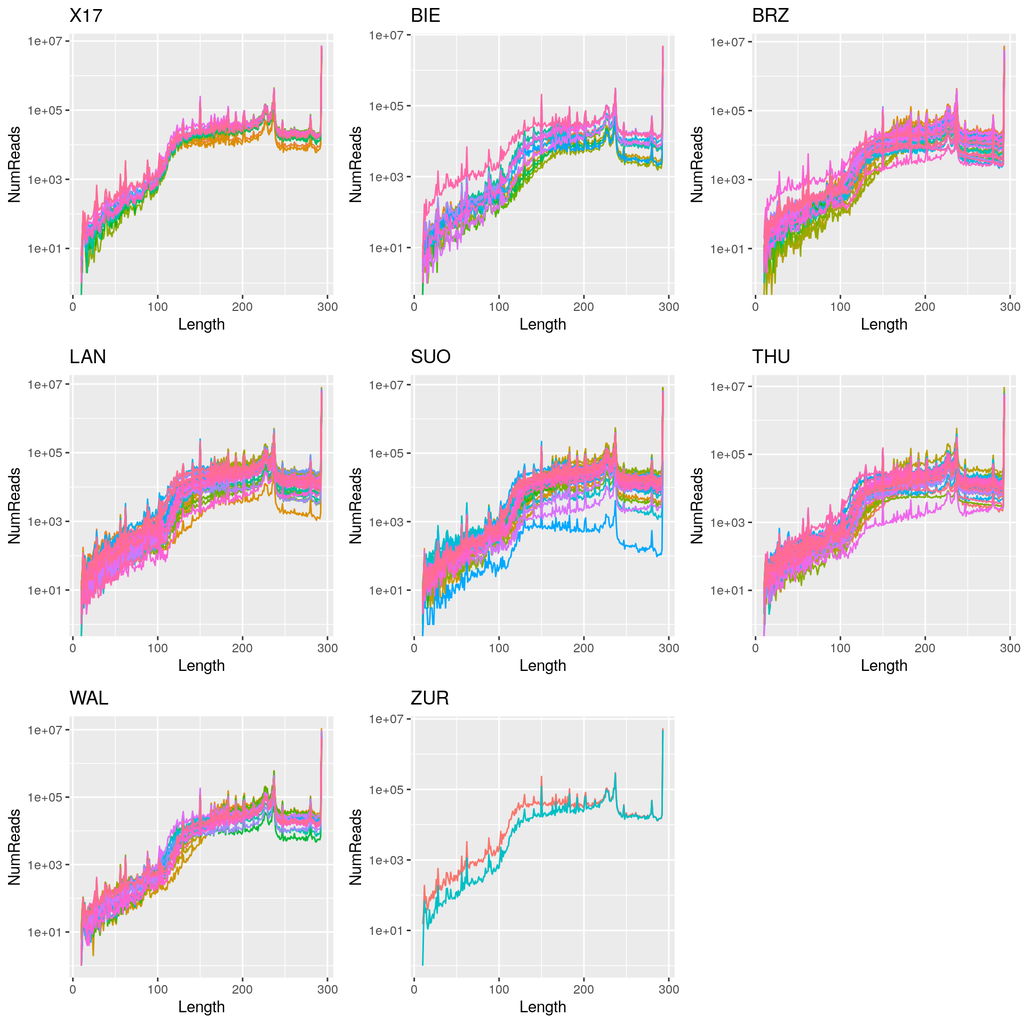

```r
library(tidyr)
library(gridExtra)
library(ggplot2)
LengthHist <- read.table('merged.stats.txt', header = TRUE)
LongHist <- pivot_longer(LengthHist, 2:281, names_to = 'Sample', values_to = 'NumReads')
Filters <- lapply(unique(substr(LongHist$Sample, 1, 3)),
                  function(x) startsWith(LongHist$Sample, x))
names(Filters) <- unique(substr(LongHist$Sample, 1, 3))

plots <- lapply(names(Filters),
                function(x) {
                   ggplot(LongHist[Filters[[x]],],
                          aes(x=Length, y=NumReads, color=Sample)) +
                      geom_line() + scale_y_log10() + guides(color = 'none') +
                      ggtitle(x)})
grid.arrange(grobs = plots, nrow = 3)
```

Two remarkable features: the distributions of merged fragment lengths are extremely similar, with all peaks matching among samples. This is very good because it means that the short DNA fragments that sneaked into the analysis are the same ones in all samples. And second, the last peak is the reason to use a log scale and indicates that in all samples there are still many reads from fragments longer than 292 base pairs, which is good. Let's see the proportions of merged and non-merged pairs.

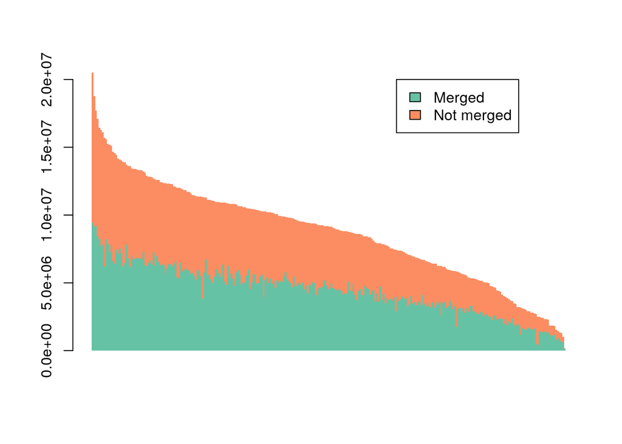

```r
library(RColorBrewer)
Merging <- data.frame(
   Sample = names(LengthHist)[2:281],
   Merged = colSums(LengthHist[1:(dim(LengthHist)[1] - 1), 2:281]),
   Paired = as.numeric(LengthHist[dim(LengthHist)[1], 2:281]),
   Total  = colSums(LengthHist[, 2:281])
)
barplot(t(as.matrix(Merging[order(Merging$Total, decreasing = TRUE), 2:3])),
        xaxt = 'n', border = NA, space = 0,
        col = brewer.pal(3, 'Set2')[c(1,2)])
legend(180, 2e+07, c('Merged', 'Not merged'), fill = brewer.pal(3, 'Set2')[c(1,2)])
```

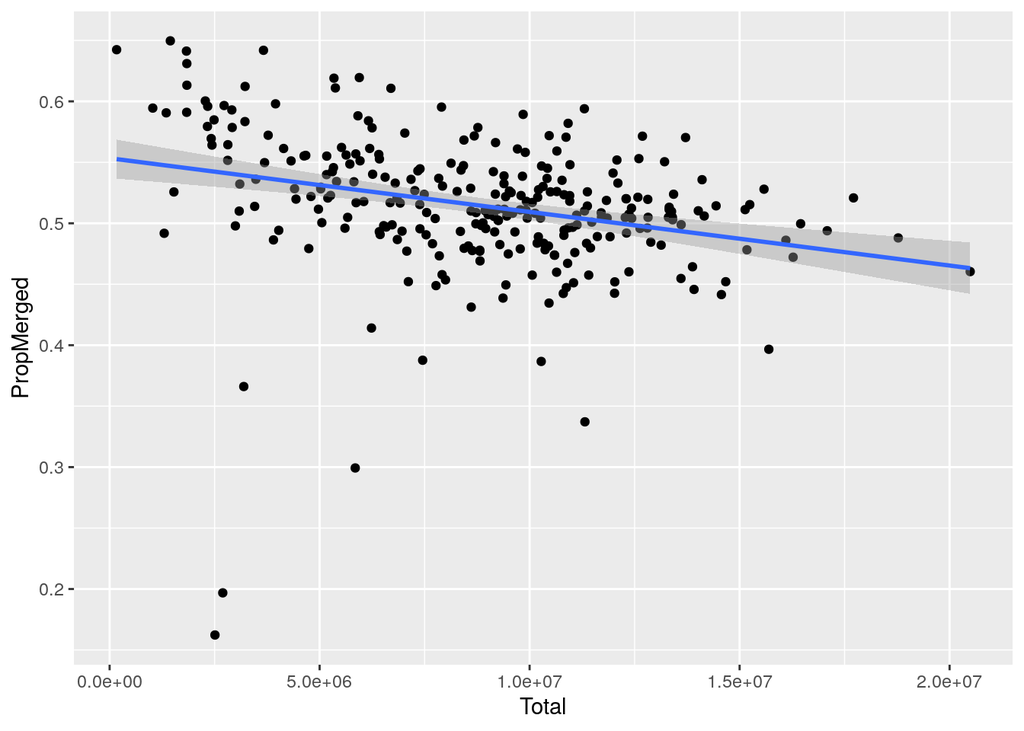

```r
Merging$PropMerged <- Merging$Merged / Merging$Total
ggplot(Merging, aes(x = Total, y = PropMerged)) + geom_point() + geom_smooth(method = 'lm')
```

About 50% of read pairs got merged. The number of non-merged reads is high enough to justify working separately with both kinds of reads.

The purpose of clustering now is to count the number of different loci, and we do not need to include reverse reads in that analysis, because the same clustering is expected using either forward or reverse reads. And artificially merging them does not seem a good idea.

## Filtering

So for the moment, I will use vsearch for the filtering before the clustering. This means that paired reads cannot be filtered together, and I assume that filtering only forward reads (R1) is enough for the purpose of clustering and counting clusters (i.e., loci).

I like the simplicity of using the number of expected errors as a filtering creteria. More than 1 sequencing error should not be tolerated. The same limit was set for the overlapping region when merging. But there are two ways to filter: either reject whole reads with more than one expected errors or to trim them in order to reduce the number of expected errors. Trimming should then be accompanied by a minimum length filter.

I decide not to trim, but to remove the whole read if more than one error is expected. The reason is that trimming would complicate clustering. Up to now I expect all merged reads from the same locus to be the same length (except for those that failed to merge, by chance). I would also ignore, for the moment, the possibility that some DNA fragments contain a restriction site that failed to be digested (I should check that).

```bash
if [ ! -d merged.clean ]; then mkdir merged.clean; fi
if [ ! -d paired.clean ]; then mkdir paired.clean; fi
if [ ! -e filtering.stats.txt ]; then
   # I use my parallelization, because --fastq_filter is not parallelized.
   NUMSAMPLES=$(ls -1 merged | wc -l)
   NUMTHREADS=40
   while [ $(( $NUMSAMPLES % $NUMTHREADS )) -ne 0 ]; do
      NUMTHREADS=$(( NUMTHREADS + 1))
   done
   NUMBATCHES=$(( NUMSAMPLES / NUMTHREADS))
   for i in $(seq 1 $NUMBATCHES); do
      LAST=$((  NUMTHREADS * i ))
      for sample in $(ls -1 merged | cut -d "." -f 1 | head -n $LAST | tail -n $NUMTHREADS); do
         if [ ! -e merged.clean/$sample.fq.gz ]; then
            vsearch --fastq_filter merged/$sample.fq.gz \
                    --fastqout - \
                    --log logs/$sample.merged.filter.log \
                    --fastq_minlen 36 \
                    --fastq_maxee 1 | \
            gzip > merged.clean/$sample.fq.gz &
         fi
      done
      wait
   done
   for i in $(seq 1 $NUMBATCHES); do
      LAST=$((  NUMTHREADS * i ))
      for sample in $(ls -1 merged | cut -d "." -f 1 | head -n $LAST | tail -n $NUMTHREADS); do
         if [ ! -e paired.clean/$sample.R1.fq.gz ]; then
            vsearch --fastq_filter paired/$sample.R1.fq.gz \
                    --fastqout - \
                    --log logs/$sample.paired.filter.log \
                    --fastq_maxee 1 | \
            gzip > paired.clean/$sample.R1.fq.gz &
         fi
      done
      wait
   done

   gawk 'BEGIN{
      print "Sample\tMerged.Kept\tMerged.Lost\tPaired.Kept\tPaired.Lost"
   }(/sequences kept/){
      split(FILENAME, A, /[./]/)
      SAMPLE = A[2]
      SAMPLELIST[SAMPLE] = 1
      TYPE = A[3]
      KEPT[SAMPLE, TYPE] = $1
      LOST[SAMPLE, TYPE] = $8
   }END{
      for (sample in SAMPLELIST) {
         print sample "\t" KEPT[sample, "merged"] "\t" \
         LOST[sample, "merged"] "\t" KEPT[sample, "paired"] "\t" \
         LOST[sample, "paired"]
      }
   }' logs/*.filter.log > filtering.stats.txt
fi
```

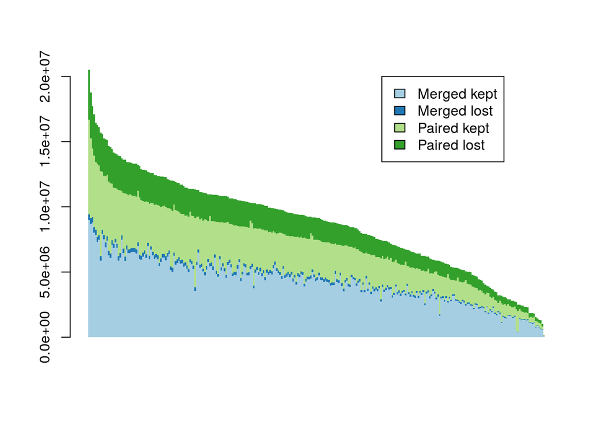

```r
Filtering <- read.table('filtering.stats.txt', header = TRUE, as.is = TRUE)
f_175 <- startsWith(Filtering$Sample, '175')
Filtering[f_175, 'Sample'] <- paste0('X', Filtering[f_175, 'Sample'])
row.names(Filtering) <- Filtering$Sample
Filtering <- Filtering[row.names(Merging),]
Palette <- brewer.pal(4, 'Paired')
barplot(t(as.matrix(Filtering[order(Merging$Total, decreasing = TRUE), 2:5])),
        xaxt = 'n', border = NA, space = 0,
        col = Palette)
legend(180, 2e+07, c('Merged kept', 'Merged lost', 'Paired kept', 'Paired lost'),
       fill = Palette)
```

When removing reads with more than 1 expected error, we loose many of the forward paired reads, but very few of the merged ones. I believe this is due to the *correction* of errors in the overlap between merged pairs. Non-merged reads usually have most errors near the end. Plus, non-merged reads could be enriched in low-quality reads that could not be paired just because they had too many errors. For the moment, I think it is better to work with only the reads that passed the filters, for clustering purposes. However, when aligning the reads to the reference genome, it would be better to repeat the filtering and maybe then trim the reads. Otherwise, we could use Trimmomatic to filter forward and reverse reads together.

## De-replication

Before clustering we need to de-replicate the files. Fastq files are very redundant, because many reads can have the exact same sequence. Clustering will not look at sequence quality. Thus, dereplication can produce a much smaller fasta file, with unique sequences represented only once. The number of times a sequence was observed is annotated in its header.

In addition to de-replicating, below I add the sample information to every sequence's header. The clustering will take that information into account to print the reports.

```bash
if [ ! -d derep ]; then mkdir derep; fi
if [ ! -d clustering.stats.txt ]; then
   # Join merged and R1, dereplicate and add sample info
   if [ ! -e derep.stats.txt ]; then
      NUMSAMPLES=$(ls -1 merged | wc -l)
      NUMTHREADS=40
      while [ $(( $NUMSAMPLES % $NUMTHREADS )) -ne 0 ]; do
         NUMTHREADS=$(( NUMTHREADS + 1))
      done
      NUMBATCHES=$(( NUMSAMPLES / NUMTHREADS))
      for i in $(seq 1 $NUMBATCHES); do
         LAST=$((  NUMTHREADS * i ))
         for sample in $(ls -1 merged | cut -d "." -f 1 | head -n $LAST | tail -n $NUMTHREADS); do
            if [ ! -e derep/$sample.fa ]; then
               cat merged.clean/$sample.fq.gz paired.clean/$sample.R1.fq.gz | \
               vsearch --derep_fulllength - \
                       --gzip_decompress \
                       --sizeout \
                       --fasta_width 0 \
                       --output - |
               gawk -v SAMPLE=$sample '(/^>/){
                  print $1 ";sample=" SAMPLE
               }(/^[^>]/){
                  print $1
               }' > derep/$sample.fa &
            fi
         done
         wait
      done
      # The following reads the de-replicated fasta files and writes a
      # matrix with the histograms of multiplicity (number of sequences
      # observed x number of times) for all samples.
      gawk 'BEGIN{
         MAXREP=30000
         SAMPLEINDEX=1
      }(FNR == 1){
         split(FILENAME, PATH, /[/.]/)
         SAMPLE = PATH[2]
         SAMPLELIST[SAMPLEINDEX] = SAMPLE
         SAMPLEINDEX++
         HEADER = HEADER "\t" SAMPLE
      }(/^>/){
         split($1, A, /;/)
         split(A[length(A) - 1], B, /=/)
         F[SAMPLE, B[2]]++
         if (B[2] > MAXREP) MAXREP = B[2]
      }END{
         print HEADER
         for (i = 1; i <= MAXREP; i++) {
            LINE = i
            for (j = 1; j <= length(SAMPLELIST); j++) {
               LINE = LINE "\t" F[SAMPLELIST[j], i] + 0
            }
            print LINE
         }
      }' derep/*.fa > derep.stats.txt
   fi
fi
```

A sequence has been seen 100652 times in at least one sample. But very few sequences appear more than 6000 times in a file.

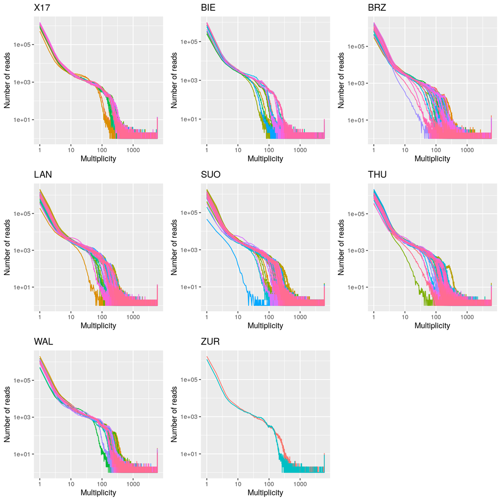

```r
Derep <- read.table('derep.stats.txt', header = TRUE)
# Pool all counts above a multiplicity of 6000 in the same bin:
Derep[6001, ] <- lapply(Derep, function(x, END) sum(x[6001:END]), END = dim(Derep)[1])
Derep <- Derep[1:6001,] + 1
Derep$Multiplicity <- 1:6001
Derep.long <- pivot_longer(Derep, 1:280, names_to = 'Sample', values_to = 'NumReads')
Filters <- lapply(unique(substr(Derep.long$Sample, 1, 3)),
                  function(x) grepl(x, Derep.long$Sample))
names(Filters) <- unique(substr(Derep.long$Sample, 1, 3))
plots <- lapply(names(Filters),
                function(lake) {
                   ggplot(Derep.long[Filters[[lake]], ],
                          aes(x = Multiplicity, y = NumReads, color = Sample)) +
                      geom_line() + guides(color = 'none') + ggtitle(lake) +
                      xlab('Multiplicity') + ylab('Number of reads') +
                      scale_y_log10() + scale_x_log10()
                })
grid.arrange(grobs = plots, nrow = 3)
```

The most abundant type of sequences are *singletons*, observed only once. But the distribution of multiplicities has a bump, indicating that many reads are repeated between 10 and more than 100 times. After clustering, many of the singletons and the low-multiplicity sequences will be assigned to clusters of similar sequences, and the distribution of multiplicity (or coverage) will become more normal.

In the plots above, the samples with much lower numbers of reads have a steeper slope.

## Clustering

Clustering is parallelized in VSEARCH. My first goal is to perform a general clustering with all samples together. This would give the total number of loci across samples. Then I will look at the coverage distribution in terms of total number of reads (across samples) per cluster. I expect a relationship between this coverage and the cluster's length. The PCR used to add indices to the DNA fragments introduced a bias: short fragments proliferate faster. Thus, clusters of short sequences should receive higher coverage. (But see below).

Because I did not trim the reads, a cluster should be composed of only reads of the same length.

I would also like to see the *sample coverage*: how many samples are represented in a cluster. To put it another way, how deep loci got sequenced in every sample. I can get this information because I included the sample of origin in the header of every sequence.

When clustering, we specify an identity threshold, usually defined in terms relative to the length of the alignment. But we filtered reads according to an absolute expected number of errors. Thus, short (merged) reads that are allowed to have one expected error will be more often split in different clusters even if they belong to the same one, because their identity will be lower, relative to their length. If short loci are erroneously split in two or more clusters more often than large loci, then their apparent coverage will be lower. To minimize the bias in cluster duplication, I could ignore clusters below a certain size.

I tried use 40 threads in clustering, but I run out of RAM. If using only one thread does not solve the memory problem, I will have to separate merged from non merged loci. Apparently, VSEARCH is not very efficient with datasets other than amplicons. The excess of diversity in random loci consumes too much memory.

```bash
if [ ! -e centroids.fa ]; then
   if [ ! -e sorted.fa ]; then
      cat derep/*.fa | \
      vsearch --sortbylength - \
              --minseqlength 100 \
              --fasta_width 0 \
              --output sorted.fa
   fi
   vsearch --cluster_smallmem sorted.fa \
           --centroids centroids.fa \
           --id 0.97 \
           --sizein \
           --sizeout \
           --strand plus \
           --threads 1 \
           --log logs/clustering.log \
           --fasta_width 0
fi

#           --consout consensus.fa \
#           --otutabout clustering.txt \
#           --clusterout_id \
```

Unfortunately, the clustering step consumes too much memory, even after reducing the number of threads to 1, skipping reads shorter than 100 nucleotides, and requesting only the centroids, instead of the consensus and the tabulated output.

# References

Rognes, Torbjørn, Tomáš Flouri, Ben Nichols, Christopher Quince, and Frédéric Mahé. 2016. “VSEARCH: A Versatile Open Source Tool for Metagenomics.” *PeerJ* 4. PeerJ Inc.: e2584.